# RACE COUNTS Health Insurance Stats

7/30/2020

## About

This page is tests whether Chris can use R well enough to get ACS data via api, calculate all RACE COUNTS-relevant statistics, upload the results to pgadmin, and generate some basic plots in R.

## Methodology

First I get county numbers and percentages of people with health insurance by race from ACS 2018 5-year estimates table 2701, as well as numbers of people for whom health insurance status is determined (the universe). Next, I calculate coefficients of variation (CVs), and remove estimates with number or percentage estimate CVs > .4, or with universes less than 150 people. Then, I calculate the best (highest) health insurance rate among races and the index of disparity (ID), or the average difference in health insurance rates among races (expressed as a percentage) for each county. Finally, I assign counties into quadrants based on above- or below-average health insurance and ID percentages.

## Scatterplot

The Scatterplot shows the distribution of counties based on health insurance rates and racial disparities among them. Note: bubble sizes are classified into five groups based on population size.

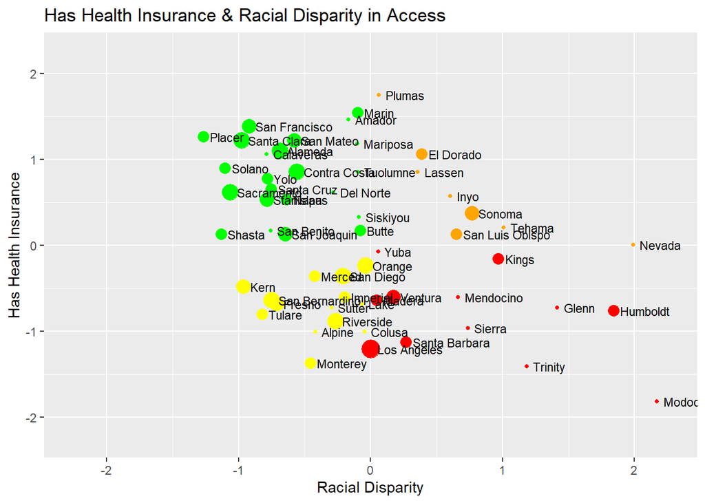

## Rank Chart

This chart tells us nothing and needs updating based on Laura’s tutorial.

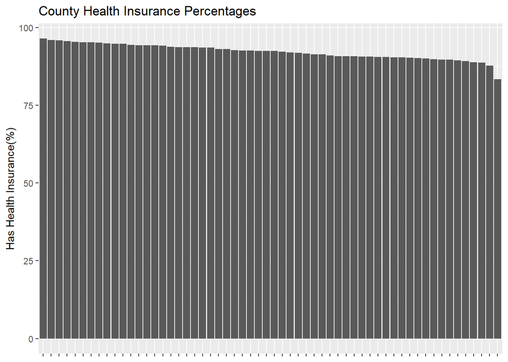

## Map

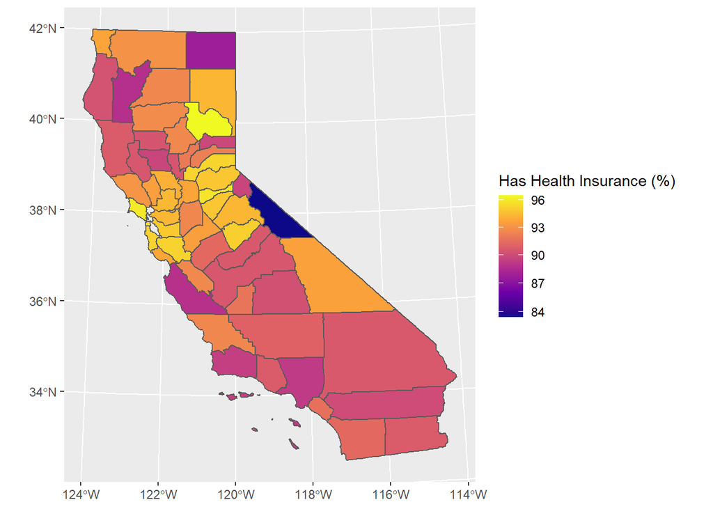